# Worked Example: Hello, World!

Johan Larsson

## Overview

Let’s get started working with R! In this worked example, we will learn how to install and use packages in R as well as perform some basic operations on vectors, matrices, and data frames. First off, if you’re familiar with other programming languages since before, you will notice that R is an *interpreted* language, which means that you don’t need to compile anything.[^1]

That means it’s very easy to write and run an R program. You simply put some R code in a text file with the ending `.R`, and then you can run that program using a terminal or a graphical user interface like R Studio. So, let’s say we have a script called `helloworld.R`. Then it’s just a matter of calling `Rscript`[^2] on that scripts, like this.

```bash
Rscript helloworld.R
```

```
## [1] "Hello, World!"
```

This is just to showcase that R is really just a program that reads and interprets text files. The `.R` (and `.Rmd`) files that you will be working with are just that: text.

## Objects in R

When you start an R session, you enter into an **environment** that stores objects that you access via their **names**. You can populate this environment with objects of your own using the `<-` operator by placing the name (or variable) you want to give your object on the left-hand side, and the object itself on the right-hand side, like this:

```r
# store the number 42 in the_meaning_of_life
the_meaning_of_life <- 42
```

Then to access this object, you simply have to refer to it as `the_meaning_of_life` (no quotation marks).

You can (usually) print the contents of any variable in R by simply calling its name in the console.

```r
the_meaning_of_life
```

```
## [1] 42
```

### Vectors

Vectors are one-dimensional arrays which store objects. Vectors can be created from functions or directly using, for instance, the `c()` function. Each vector can only store objects of *a single type*, which means that you cannot combine the different data types in R, such as **character**, **numeric**, and **integer**. If you still decide to try to, however, you will soon notice that R won’t tell you no. Instead, R simply *converts* the vector to a single type based on a few defaults.

We talked about this in the lecture, so try to see if you can figure out how the following vectors will be converted (if at all):

```r
c("a", 1, TRUE)
c(1L, 1) # 1L = integer of value 1
c(NA, "a")
c(1, 1/3)
```

Having numeric values be converted to characters is seldom what you want. The conversion from integers to doubles if often not a big problem, but can lead to improper formatting of things such as axis labels in a plot.

We can manipulate vectors algebraically using standard arithmetic operators.

```r
1:2 + c(3, 9)      # adding two vectors together
```

```
## [1]  4 11
```

```r
1.6 / 2
```

```
## [1] 0.8
```

```r
c(1, 10) * 2       # 2 is multiplied with each element
```

```
## [1]  2 20
```

```r
c(NA, 3.123, pi)^2 # pi is an object that's always available
```

```
## [1]       NA 9.753129 9.869604
```

```r
c(1, 2, 3, 4) * c(1, 2)
```

```
## [1] 1 4 3 8
```

What do you think happens if the shorter vector’s length is *not* a multiple of the longer vector’s length? We’ll find out a bit later.

### Special Values

`NA` is a special value used to denote missing data. There is also another type of value called `NULL`, which is exactly what is sounds like: nothing.

We can assign `NULL` to a variable

```r
a <- NULL
```

but note that creating a vector with several values, some of them `NULL`, will give a different result.

```r
a <- c(NULL, "a")
a
```

```
## [1] "a"
```

To access an element in a vector, we can use the `[` operator:

```r
x <- c("a", "b", "c", "e")
x[1]
```

```
## [1] "a"
```

And to access several elements at once, you can use a vector of indices.

```r
x[c(1, 4)]
```

```
## [1] "a" "e"
```

Accessing a contiguous sub-vector is often desirable, in which case the `:` operator is a useful tool. It creates a vector of indices.

```r
1:4
```

```
## [1] 1 2 3 4
```

We can use this to access a range of elements from `x`.

```r
x[1:3]
```

```
## [1] "a" "b" "c"
```

It is also possible to modify elements in vectors in the same fashion.

```r
x[1:2] <- c("foo", "bar")
x
```

```
## [1] "foo" "bar" "c"   "e"
```

Similarly, we can *remove* certain elements by negative indexing in the following way.

```r
x[-1]
```

```
## [1] "bar" "c"   "e"
```

```r
x[-(1:2)]
```

```
## [1] "c" "e"
```

Notice the use of parentheses in the second example. What do you think `x[-1:2]` would give us?

### Matrices

Matrices are two-dimensional arrays. Just like vectors, they can only contain a single type of values.

```r
m <- rbind(c(1, 2),
           c(3, NA))
m
```

```
##      [,1] [,2]
## [1,]    1    2
## [2,]    3   NA
```

We can access separate rows and columns by separating row and column indices with a comma.

```r
m[1, 2]
```

```
## [1] 2
```

To select an entire column, simply omit the first argument (or vice verse to select an entire row).

```r
m[1, ]
```

```
## [1] 1 2
```

```r
m[, 2]
```

```
## [1]  2 NA
```

### Data Frames

Data frames look a lot like matrices except they allow each column to have a different type. Most of the data that you will encounter in this course will be stored as data frames (or as tibbles, but more on that later).

The following code creates a simple data.frame, using the `data.frame()` function.

```r
d <- data.frame(a = 1:3,
                b = letters[1:3])
d
```

```
##   a b
## 1 1 a
## 2 2 b
## 3 3 c
```

```r
d$a
```

```
## [1] 1 2 3
```

```r
d$b
```

```
## [1] "a" "b" "c"
```

## Packages

### Installing Packages

One of R’s strengths is the wide-ranging package ecosystem it sports. One package that we will use a lot during this course is **ggplot2**. If you don’t yet have that package installed, we will now do so by calling the `install.packages()` function, using **ggplot2** as the first argument. Simply call the code below.

```r
install.packages("ggplot2")
```

When you call this line, R will also install all of the *dependencies* that come with ggplot2, which includes other packages. If this is the first time you run R, you might also be prompted to choose a CRAN mirror. A good default choice is `"https://cloud.r-project.org"`.

### Using Packages

To use a package in R, you can call the `library(<package-name>)` function, after which all of that packages functions—and often also its datasets—will be available to you directly in your working environment.

Load the **ggplot2** package we just installed by calling the following.

```r
library(ggplot2) # library("ggplot2") would work as well!
```

Sometimes we will also use `<package>::function()` to call a function from a specific package. In this case, you don’t need to call library first. This is particularly useful if you load two packages that export two functions with the same names.

In the following line, we create a plot in **ggplot2** with this syntax, but bear in mind that this is just for show since we’re already loaded the package using `library()`.

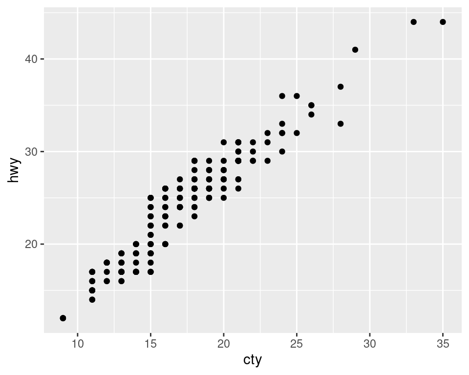

```r
ggplot2::ggplot(mpg, ggplot2::aes(cty, hwy)) +
  ggplot2::geom_point()
```